# Nested Data

2022-11-17

```r
df_individual
```

```
## # A tibble: 526 × 21
##    CodeSe…¹ gender   age exper…² exper…³ worki…⁴ numbe…⁵ possi…⁶ numbe…⁷ commu…⁸
##    <chr>     <dbl> <dbl>   <dbl>   <dbl>   <dbl>   <dbl>   <dbl>   <dbl>   <dbl>
##  1 RPCP1         0    56    24      20       100       1       0       3     120
##  2 RPCP1         1    36     3       3        80       1       0       2      30
##  3 RPCP1         0    54    28      28       100       1       0       2      60
##  4 RPCP1         1    28     6       3        80       1       0       1      30
##  5 RPCP1         1    24     3       1       100       1       1       0      50
##  6 RPCP1         1    40     7       3        80       1       0       2      60
##  7 RPCP1         1    31    10       9        80       1       0       2      30
##  8 RPCP1         1    26     5       1.5     100       1       0       0     120
##  9 RPCP1         1    22     2       1       100       3       0       0      10
## 10 RPCP1         1    25     2.5     2.5     100       1       1       0      45
## # … with 516 more rows, 11 more variables: NHP_S <dbl>, NHP_E <dbl>,
## #   `current fatigue state` <dbl>, `stress level` <dbl>,
## #   `support from supervisors` <dbl>, `support from colleagues` <dbl>,
## #   `marital status` <dbl>, `schedule changes` <dbl>, `overtime hours` <dbl>,
## #   `shift assignment in the previous month` <dbl>, profession <dbl>, and
## #   abbreviated variable names ¹CodeService, ²`experience in profession`,
## #   ³`experience in current position`, ⁴`working quota`, ⁵`number of breaks`, …
## # ℹ Use `print(n = ...)` to see more rows, and `colnames()` to see all variable names
```

```r
df_unit
```

```
## # A tibble: 30 × 9
##    CodeService number …¹ Turno…² staff…³ staff…⁴ staff…⁵ shift…⁶ type …⁷ prese…⁸
##    <chr>           <dbl>   <dbl>   <dbl>   <dbl>   <dbl>   <dbl>   <dbl>   <dbl>
##  1 LMRP1              12   0.185   0.5     0.5     0.5         0       2       0
##  2 HTDC1               6   0.174   0.667   0.667   0.667       0       1       0
##  3 BCHC1              12   0.375   0.75    0.667   0.708       0       1       0
##  4 BCHM1              30   0.176   0.567   0.533   0.55        0       0       1
##  5 LRBC1              20   0.143   0.688   0.688   0.688       0       1       0
##  6 EGPM1              20   0.125   0.55    0.5     0.525       0       0       1
##  7 PSLC2              12   0.196   0.833   0.5     0.667       0       1       0
##  8 SATM1              18   0.161   0.5     0.5     0.5         1       0       1
##  9 PSLC1              14   0.132   0.714   0.714   0.714       0       1       0
## 10 JVRP1               8   0.324   1       0.833   0.917       0       2       1
## # … with 20 more rows, and abbreviated variable names ¹`number of beds`,
## #   ²Turnover, ³`staff-to-patient ratio day`, ⁴`staff-to-patient ratio night`,
## #   ⁵`staff-to-patient ratio average`, ⁶`shift work organisation`,
## #   ⁷`type of ICU`, ⁸`presence of continious care bed`
## # ℹ Use `print(n = ...)` to see more rows
```

## The Basic Problem

Multilevel models are developed for the analysis of hierarchically structured data. A hierarchy consists of lower level observations nested within higher level(s).

*Example*:

- Level 1: measurement at one time
- Level 2: student
- Level 3: class
- Level 4: school
- Level 5: district
- …

## The linear multilevel model

Special regression that is suitable for hierarchical data.

Difference to *traditional* regression:  
More than one error term (1+ per level)

Let *i* be the index for Level 1 units (\(i\) = 1,…,\(n_j\)) and *j* be the index for Level 2 units (\(j\) = 1,…,\(J\)) then the DV \(Y_{ij}\) at Level 1 is explained by:

\(Y_{ij}=\alpha_j+\beta_jX_{ij}+\epsilon_{ij}\)

\(\alpha_j= \mu+\gamma Z_j + u_j\)  
\(\beta_j=\theta+ \eta Z_j + v_j\)

where \(X_{ij}\) is a Level 1 variable, and \(Z_j\) is a Level 2 variable

## Why we can’t just use normal regression.

1. faithful to the data structure
2. individuals within a group are similar (*correlated*) and therefor include less information than independent individuals (effective *n* is overestimated and SEs are too small)
3. effects on different levels don’t necessarily need be the same

## similar cases share information

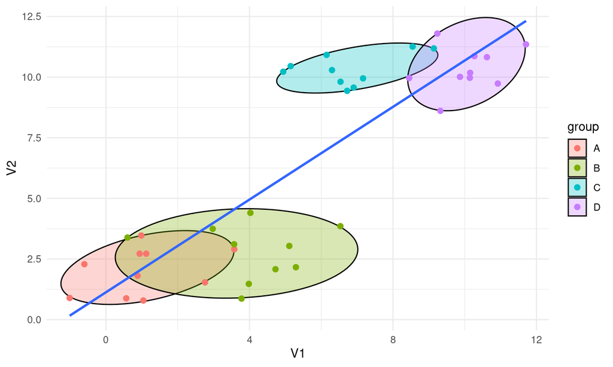

Would the regression line look much different with just one point per group?

## effects on different levels can differ

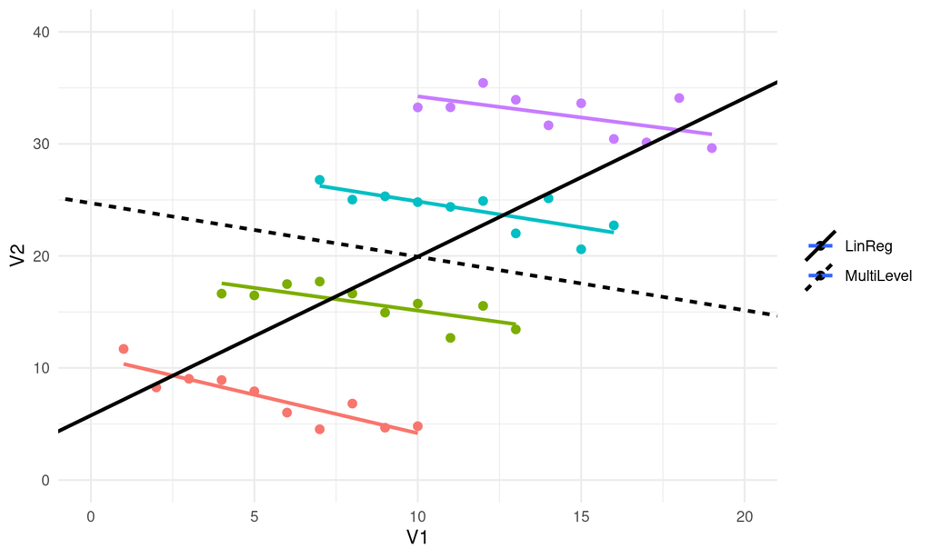

## Another thing is different: CENTERING

2 Options:

- **grand mean centering**
  - centering like in normal regression
  - linear transformation -> only intercept changes (model is equivalent)
- **group mean centering**
  - subtract the individual’s group mean from the individual’s score
  - parameters change -> model is NOT equivalent
  - group means can be added as group predictors (to disentangle micro and macro level contributions)

## When to center how?

This is a complex question (e.g., see Hofman & Gavin (1998), [Paccagnella (2006)](http://journals.sagepub.com/doi/10.1177/0193841X05275649), [Enders & Tofighi (2007)](http://dx.doi.org/10.1037/1082-989X.12.2.121), and [Hamaker & Grasman (2015)](https://www.frontiersin.org/articles/10.3389/fpsyg.2014.01492) for discussions) with no easy answer.

- Raw:
  - if one is interested in intercept and intercept variance when predictor is 0
- Grand mean centering:
  - often used for higher level variable to facilitate interpretation
  - interest in a L2 predictor and want to control for L1 covariates
  - interest in interactions between L2 variables
- Group mean centering:
  - purpose is disentangling effects on different levels (add group means as predictor)
  - if multilevel collinearity is high (e.g., student’s age at L1 and school level at L2)
  - L1 association between \(X\) and \(Y\) is of substantive interest
  - cross-level interactions and L1 interactions

**Correct centering depends solely on your question!** Use different centerings for different questions (even in 1 analyses block).